# UtahLake_TributaryData

Kateri Salk

1/5/2021

## Load data

Data were loaded from spreadsheets obtained by Utah DWQ:

```r
# tributary data
trib <- read.csv("./Data/Processed/ul_Tribdata_wqp_processed_2020-12-17.csv")
# facility data
fac <- read.csv("./Data/Processed/ul_Facilitydata_wqp_processed.csv")
# watershed spatial data
wshds <- read_sf("./Data/GIS/ulSubWshdsWGS84.shp")
# sampling activity logs
activitylog <- read.csv("./Data/Processed/UL_Trib_SampleActivities_exported 12-17-20.csv")
# groundwater data
gw <- read.csv("./Data/Processed/ul_wqp_gwdata_processed_2021-01-07.csv")
# precipitation and evaporation data
p_et <- read.xlsx("./Data/Processed/ULEFDCFlowBoundaries_WY2006-2018.xlsx",
                  sheet = "Precip-ET", startRow = 2)
```

## Data processing

### Watersheds

Watersheds were divided into monitored and unmonitored and arranged in clockwise order.

```r
wshds_monitored <- wshds %>%
  filter(Monitored_ == "YES")

wshds_monitored$WS_Name <-
  factor(wshds_monitored$WS_Name,
         levels = c("Lake Mountain - Israel Canyon", "Dry Creek - Saratoga",
                    "Lehi Spring Creek", "American Fork River", "Timp SSD",
                    "Lindon Drain", "Powell Slough Major", "Provo River",
                    "Mill Race", "Hobble Creek", "Dry Creek - Spanish Fork",
                    "Spanish Fork River", "4000 South Drain Spanish Fork",
                    "Benjamin Slough", "Currant Creek"))
levels(wshds_monitored$WS_Name)
```

```
##  [1] "Lake Mountain - Israel Canyon" "Dry Creek - Saratoga"
##  [3] "Lehi Spring Creek"             "American Fork River"
##  [5] "Timp SSD"                      "Lindon Drain"
##  [7] "Powell Slough Major"           "Provo River"
##  [9] "Mill Race"                     "Hobble Creek"
## [11] "Dry Creek - Spanish Fork"      "Spanish Fork River"
## [13] "4000 South Drain Spanish Fork" "Benjamin Slough"
## [15] "Currant Creek"
```

### Tributary data

Tributary dataset was filtered for:

1. Variables pertaining to C, N, P, or flow (discharge)
2. Years 2010-2020

Flow data were converted to cubic feet/sec (cfs) when units originally appeared as gallon/min, cubic meters/sec, and million gallons/day.

```r
trib$ActivityStartDate <- as.Date(trib$ActivityStartDate)
# unique(trib$CharacteristicName)
trib$ResultMeasureValue <- as.numeric(as.character(trib$ResultMeasureValue))
trib_wq <- trib %>%
  # Set nondetects (qualifier code U) as 1/2 MDL.
  # Qualifier code J is above detection but below reporting. Values retained as-is.
  # REVISIT: What does qualifier code Q mean? One sample for ammonium at 0.062
  mutate(ResultMeasureValue = case_when(MeasureQualifierCode == "U" ~ MethodDetectionLevel/2,
                                        TRUE ~ ResultMeasureValue)) %>%
  filter(CharacteristicName %in%
           c("Ammonia-nitrogen as N", "Carbon", "Nitrate as N", "Organic carbon",
             "Ammonium", "Carbonate", "Inorganic carbon", "Nitrate", "Nitrogen",
             "Phosphorus", "Ammonia and ammonium",
             "Inorganic nitrogen (nitrate and nitrite)", "Nitrite", "Orthophosphate",
             "Kjeldahl nitrogen", "Nitrogen, mixed forms (NH3), (NH4), organic, (NO2) and (NO3)",
             "Organic Nitrogen", "Ammonia-nitrogen", "Phosphate-phosphorus",
             "Total Kjeldahl nitrogen")) %>%
  filter(ResultMeasure.MeasureUnitCode %in% c("ueq/L", "mg/l", "mg/l as N", "<NA>", "mg/l as P")) %>%
  select(MonitoringLocationIdentifier:ResultSampleFractionText,
         OrganizationIdentifier:MonitoringLocationTypeName, LatitudeMeasure,
         LongitudeMeasure, ResultMeasureValue, ResultMeasure.MeasureUnitCode,
         ResultStatusIdentifier) %>%
  mutate(Month = month(ActivityStartDate),
         Year = year(ActivityStartDate)) %>%
  filter(Year >= 2010) %>%
  droplevels() %>%
  filter(!is.na(ResultMeasureValue)) %>%
  select(-SampleDepthValue, -RelativeDepth, -ResultMeasure.MeasureUnitCode) %>%
  unite("Variable", CharacteristicName:ResultSampleFractionText)

trib_flow <- trib %>%
  filter(CharacteristicName %in% c("Flow", "Stream flow, instantaneous", "Stream flow, mean. daily")) %>%
  droplevels() %>%
  #filter(ResultStatusIdentifier != "Provisional") %>% # can filter out provisional data
  select(MonitoringLocationIdentifier:ResultSampleFractionText,
         OrganizationIdentifier:MonitoringLocationTypeName, LatitudeMeasure,
         LongitudeMeasure, ResultMeasureValue, ResultMeasure.MeasureUnitCode,
         ResultStatusIdentifier) %>%
  select(-SampleDepthValue, -RelativeDepth, -ResultSampleFractionText,
         -MonitoringLocationTypeName, -CharacteristicName) %>%
  group_by(MonitoringLocationIdentifier, ActivityStartDate, OrganizationIdentifier,
           OrganizationFormalName, MonitoringLocationName, LatitudeMeasure,
           LongitudeMeasure, ResultMeasure.MeasureUnitCode, ResultStatusIdentifier) %>%
  summarise(ResultMeasureValue = mean(ResultMeasureValue)) %>%
  mutate(Month = month(ActivityStartDate),
         Year = year(ActivityStartDate)) %>%
  filter(Year >= 2010) %>%
  droplevels() %>%
  pivot_wider(names_from = ResultMeasure.MeasureUnitCode, values_from = ResultMeasureValue) %>%
  # USGS data has both cfs and cms, always duplicated. remove cfs.
  select(-'ft3/s')
```

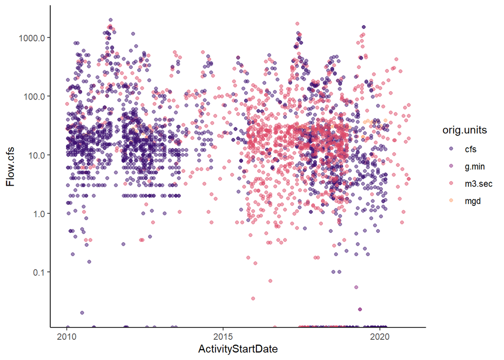

```r
colnames(trib_flow)[11:14] <- c("m3.sec", "cfs", "mgd", "g.min")

# convert everything to cfs
trib_flow$mgd <- trib_flow$mgd/0.646317
trib_flow$g.min <- trib_flow$g.min*0.002228017
trib_flow$m3.sec <- trib_flow$m3.sec*35.3147

trib_flow_long <- trib_flow %>%
  pivot_longer(cols = c("cfs", "mgd", "g.min", "m3.sec"),
               names_to = "orig.units", values_to = "Flow.cfs") %>%
  drop_na(Flow.cfs)

# conversions seem to match up
ggplot(trib_flow_long, aes(x = ActivityStartDate, y = Flow.cfs, color = orig.units)) +
  geom_point(alpha = 0.5) +
  scale_y_log10() +
  scale_color_viridis_d(option = "magma", begin = 0.2, end = 0.8)
```

### Find non-sampled dates

A sample type of “11” indicates a site was not sampled. A sample type of “10” indicates there was no flow. The latter should appear in the flow data as a zero; this was verified by inspecting the two datasets.

Locations and dates when sites were not sampled:

```
##  [1] LOWER S FK PROVO R AT GAGING STATIION
##  [2] N FK PROVO R AB CNFL / PROVO R AT WILDWOOD
##  [3] CURRANT CK AB MONA RES
##  [4] Timpanogos Effluent below constructed duck ponds
##  [5] Dry Ck Near Utah Lake-WLA
##  [6] DRY CK EAST TRIBUTARY
##  [7] AMERICAN FK CK 2.5MI S OF AM FK CITY
##  [8] Powell Slough WMA North Outfall to Utah Lake
##  [9] Powell Slough WMA South Outfall to Utah Lake
## [10] Saratoga Springs at Cedar Valley
## 10 Levels: AMERICAN FK CK 2.5MI S OF AM FK CITY ... Timpanogos Effluent below constructed duck ponds
```

```
##  [1] "2011-01-26" "2014-02-19" "2012-01-19" "2012-02-15" "2012-03-21"
##  [6] "2012-04-10" "2012-06-20" "2012-07-25" "2011-10-27" "2011-11-16"
## [11] "2011-12-06" "2011-12-07" "2017-05-17" "2017-07-10" "2017-12-20"
## [16] "2017-12-22" "2018-01-10" "2018-02-15" "2018-03-13" "2018-04-19"
## [21] "2018-05-17" "2018-11-20" "2019-05-14" "2019-06-13" "2019-06-17"
## [26] "2019-07-08" "2019-08-12" "2019-09-24" "2019-09-23" "2019-10-08"
## [31] "2019-11-04" "2019-12-10"
```

### Facility data

Tributary dataset was filtered for:

1. Variables pertaining to C, N, P, or flow (discharge)
2. Years 2010-2020

Flow data were converted to cubic feet/sec (cfs) when units originally appeared as gallon/min, cubic meters/sec, and million gallons/day.

```r
fac$datetime <- as.POSIXct(fac$datetime)
#unique(fac$CharacteristicName)

fac_wq <- fac %>%
  # Set nondetects (qualifier code U) as 1/2 MDL.
  # Qualifier code J is above detection but below reporting. Values retained as-is.
  # REVISIT: What does qualifier code Q mean? One sample for ammonium at 0.062
  mutate(ResultMeasureValue = case_when(MeasureQualifierCode == "U" ~ MethodDetectionLevel/2,
                                        TRUE ~ ResultMeasureValue)) %>%
  filter(CharacteristicName %in%
           c("Ammonia-nitrogen as N", "Carbon", "Nitrate as N", "Organic carbon",
             "Ammonium", "Carbonate", "Inorganic carbon", "Nitrate", "Nitrogen",
             "Phosphorus", "Ammonia and ammonium",
             "Inorganic nitrogen (nitrate and nitrite)", "Nitrite", "Orthophosphate",
             "Kjeldahl nitrogen", "Nitrogen, mixed forms (NH3), (NH4), organic, (NO2) and (NO3)",
             "Organic Nitrogen", "Ammonia-nitrogen", "Phosphate-phosphorus",
             "Total Kjeldahl nitrogen")) %>%
  filter(ResultMeasure.MeasureUnitCode %in% c("ueq/L", "mg/l", "mg/l as N", "<NA>", "mg/l as P")) %>%
  select(MonitoringLocationIdentifier:LongitudeMeasure, ResultMeasureValue,
         ResultMeasure.MeasureUnitCode, ResultStatusIdentifier) %>%
  mutate(Month = month(datetime),
         Year = year(datetime)) %>%
  filter(Year >= 2010) %>%
  droplevels() %>%
  filter(!is.na(ResultMeasureValue)) %>%
  select(-SampleDepthValue, -RelativeDepth, -ResultMeasure.MeasureUnitCode) %>%
  unite("Variable", CharacteristicName:ResultSampleFractionText)

# match date field with trib
colnames(fac_wq)[2] <- "ActivityStartDate"


fac_flow <- fac %>%
  filter(CharacteristicName == "Flow") %>%
           #c("Height, gage", "Stream flow, instantaneous", "Stream flow, mean. daily")) %>%
  droplevels() %>%
  #filter(ResultStatusIdentifier != "Provisional") %>% # can filter out provisional data
  select(MonitoringLocationIdentifier:LongitudeMeasure, ResultMeasureValue,
         ResultMeasure.MeasureUnitCode, ResultStatusIdentifier) %>%
  select(-SampleDepthValue, -RelativeDepth, -ResultSampleFractionText,
         -MonitoringLocationTypeName, -CharacteristicName) %>%
  group_by(MonitoringLocationIdentifier, datetime, OrganizationIdentifier,
           OrganizationFormalName, MonitoringLocationName, LatitudeMeasure,
           LongitudeMeasure, ResultMeasure.MeasureUnitCode, ResultStatusIdentifier) %>%
  summarise(ResultMeasureValue = mean(ResultMeasureValue)) %>%
  mutate(Month = month(datetime),
         Year = year(datetime)) %>%
  filter(Year >= 2010) %>%
  droplevels() %>%
  pivot_wider(names_from = ResultMeasure.MeasureUnitCode, values_from = ResultMeasureValue)
fac_flow$datetime <- as.Date(fac_flow$datetime)
colnames(fac_flow)[2] <- "ActivityStartDate"

colnames(fac_flow)[11:14] <- c("mgd", "cfs", "g.min", "m3.sec")

# convert everything to cfs
fac_flow$mgd <- fac_flow$mgd/0.646317
fac_flow$g.min <- fac_flow$g.min*0.002228017
fac_flow$m3.sec <- fac_flow$m3.sec*35.3147

fac_flow_long <- fac_flow %>%
  pivot_longer(cols = c("cfs", "mgd", "g.min", "m3.sec"),
               names_to = "orig.units", values_to = "Flow.cfs") %>%
  drop_na(Flow.cfs)
```

### Combine trib and fac data

Tributary and facility water quality and flow datasets were combined.

### USGS gage data for missing discharge

```r
USGS_flow <- readNWISdv(siteNumbers = c("10146400", "10150500",
                                         "10153100", "10163000"),
                         parameterCd = "00060",
                         startDate = "2010-01-01")

USGS_flow_processed <- USGS_flow %>%
  mutate(WS_Name = case_when(site_no == "10146400" ~ "Currant Creek",
                             site_no == "10150500" ~ "Spanish Fork River",
                             site_no == "10153100" ~ "Hobble Creek",
                             site_no == "10163000" ~ "Provo River")) %>%
  select(WS_Name, Date, X_00060_00003)

colnames(USGS_flow_processed) <- c("WS_Name", "ActivityStartDate", "Flow.USGS.cfs")
```

### Groundwater (spring and well) data

REVISIT

### Precipitation and Evapotranspiration data

TO DO: Use area vs. elevation relationship to establish average monthly lake area, with variability quantified.

REVISIT: P and ET only available 2005-2018 from EFDC output. We can only use four years of data if we restrict to 2015 onward. Should we use all years?

### Create spatial datasets for tributary and facility datasets

1. Intersect stations with watersheds
2. Join water quality data with intersected dataset
3. If a station is not associated with a watershed, assign it
4. Determine downstream stations in watersheds

Sites located downstream of diversion

- UTAHDWQ_WQX-4995465
- WFWQC_UT-4995467
- UTAHDWQ_WQX-4995312
- UTAHDWQ_WQX-4995578
- WFWQC_UT-4995575
- UTAHDWQ_WQX-4995578
- WFWQC_UT-4995575

Sites that may be backwatered at times

- WFWQC_UT-4917712
- WFWQC_UT-4994958
- UTAHDWQ_WQX-4995465
- WFWQC_UT-4995467
- WFWQC_UT-4996536
- UTAHDWQ_WQX-4995210
- UTAHDWQ_WQX-4995230
- WFWQC_UT-4995210
- WFWQC_UT-4995575

Intermittent sites

- UTAHDWQ_WQX-4994804
- UTAHDWQ_WQX-4994792

Effluent-dominated sites

- UTAHDWQ_WQX-4996040
- WFWQC_UT-4996040

Sites included in ULWQS SAP

- UTAHDWQ_WQX-5919910
- UTAHDWQ_WQX-4994960
- UTAHDWQ_WQX-4995465
- UTAHDWQ_WQX-4994804
- UTAHDWQ_WQX-4996040
- UTAHDWQ_WQX-4996100
- UTAHDWQ_WQX-4994792
- UTAHDWQ_WQX-4994950
- UTAHDWQ_WQX-4995120
- UTAHDWQ_WQX-4996540
- UTAHDWQ_WQX-4995210
- UTAHDWQ_WQX-4995230
- UTAHDWQ_WQX-4996680
- UTAHDWQ_WQX-4995578
- UTAHDWQ_WQX-4995041
- WFWQC_UT-4995043

```r
trib_fac_sites <- trib_fac_wq_flow %>%
  ungroup() %>%
  select(MonitoringLocationIdentifier, MonitoringLocationName,
           MonitoringLocationTypeName, LatitudeMeasure, LongitudeMeasure) %>%
  distinct() %>%
  mutate(SiteType = ifelse(MonitoringLocationTypeName %in%
                  c("Canal Drainage", "Canal Irrigation", "Canal Transport"), "Canal",
                ifelse(MonitoringLocationTypeName %in% c("River/Stream", "Stream", "Stream: Ditch"), "Stream",
                       ifelse(MonitoringLocationTypeName %in% c("Facility Industrial", "Facility Other"), "Facility",
                              "Storm Sewer"))))


trib_fac_sites_sf <- st_as_sf(trib_fac_sites, coords = c("LongitudeMeasure", "LatitudeMeasure"),
                              crs = 4326, dim = "XY") #CRS = WGS84


trib_fac_sites_intersect <- trib_fac_sites_sf %>%
  st_intersection(wshds) %>%
  left_join(trib_fac_wq_flow, .,)

unique(trib_fac_sites_intersect$MonitoringLocationName[is.na(trib_fac_sites_intersect$WS_Name)])
```

```
##  [1] Provo River Delta Restoration
##  [2] JORDAN R AT UTAH L OUTLET U121 XING
##  [3] Powell Slough WMA North Outfall to Utah Lake
##  [4] Powell Slough WMA South Outfall to Utah Lake
##  [5] Dry Ck Near Utah Lake-WLA
##  [6] Unnamed flow at 4000 West @ mouth
##  [7] American Fork River at mouth
##  [8] Timpanogos WWTP at Utah Lake mouth
##  [9] Lindon Drain at Utah Lake Inlet
## [10] Beer Creek at Utah Lake mouth
## [11] Hobble Creek at Utah Lake mouth
## [12] Mill Race at mouth 1.25 miles west of I-15
## [13] Dry Creek North Fork @ Confluence
## [14] Dry Creek South Fork @ Confluence
## 153 Levels: AMERICAN FK CK 2.5MI S OF AM FK CITY ...
```

```r
unique(trib_fac_sites_intersect$MonitoringLocationIdentifier[is.na(trib_fac_sites_intersect$WS_Name)])
```

```
##  [1] UTAHDWQ_WQX-4917343 UTAHDWQ_WQX-4994790 UTAHDWQ_WQX-4995210
##  [4] UTAHDWQ_WQX-4995230 UTAHDWQ_WQX-4996040 WFWQC_UT-4917712
##  [7] WFWQC_UT-4994958    WFWQC_UT-4995043    WFWQC_UT-4995075
## [10] WFWQC_UT-4995210    WFWQC_UT-4995467    WFWQC_UT-4996040
## [13] WFWQC_UT-4996096    WFWQC_UT-4996536    WFWQC_UT-4996047
## [16] WFWQC_UT-4996048
## 167 Levels: UTAHDWQ_WQX-4917343 UTAHDWQ_WQX-4993000 ... WFWQC_UT-4996020
```

```r
unique(trib_fac_sites_intersect$WS_Name)
```

```
##  [1] NA                              "Lehi Drain 2"
##  [3] "Lake Mountain - Israel Canyon" "Dry Creek - Saratoga"
##  [5] "Lehi Spring Creek"             "American Fork River"
##  [7] "Timp SSD"                      "Lindon Drain"
##  [9] "Powell Slough Major"           "Currant Creek"
## [11] "Benjamin Slough"               "Spanish Fork River"
## [13] "Dry Creek - Spanish Fork"      "Provo Bay 3"
## [15] "Provo Bay 5"                   "Hobble Creek"
## [17] "Mill Race"                     "Provo River"
## [19] "Vineyard Drain 6"              "4000 South Drain Spanish Fork"
```

```r
trib_fac_sites_intersect$WS_Name[trib_fac_sites_intersect$MonitoringLocationName ==
                                   "Powell Slough WMA North Outfall to Utah Lake"] <- "Powell Slough Major"

trib_fac_sites_intersect$WS_Name[trib_fac_sites_intersect$MonitoringLocationName ==
                                   "Powell Slough WMA South Outfall to Utah Lake"] <- "Powell Slough Major"

trib_fac_sites_intersect$WS_Name[trib_fac_sites_intersect$MonitoringLocationName ==
                                   "Dry Ck Near Utah Lake-WLA"] <- "Dry Creek - Spanish Fork"

trib_fac_sites_intersect$WS_Name[trib_fac_sites_intersect$MonitoringLocationName ==
                                   "Mill Race at mouth 1.25 miles west of I-15"] <- "Mill Race"

trib_fac_sites_intersect$WS_Name[trib_fac_sites_intersect$MonitoringLocationName ==
                                   "Hobble Creek at Utah Lake mouth"] <- "Hobble Creek"

trib_fac_sites_intersect$WS_Name[trib_fac_sites_intersect$MonitoringLocationName ==
                                   "Beer Creek at Utah Lake mouth"] <- "Benjamin Slough"

trib_fac_sites_intersect$WS_Name[trib_fac_sites_intersect$MonitoringLocationName ==
                                   "Lindon Drain at Utah Lake Inlet"] <- "Lindon Drain"

trib_fac_sites_intersect$WS_Name[trib_fac_sites_intersect$MonitoringLocationName ==
                                   "Timpanogos WWTP at Utah Lake mouth"] <- "Timp SSD"

trib_fac_sites_intersect$WS_Name[trib_fac_sites_intersect$MonitoringLocationName ==
                                   "American Fork River at mouth"] <- "American Fork River"

trib_fac_sites_intersect$WS_Name[trib_fac_sites_intersect$MonitoringLocationName ==
                                   "Unnamed flow at 4000 West @ mouth"] <- "4000 South Drain Spanish Fork"

trib_fac_sites_intersect$WS_Name[trib_fac_sites_intersect$MonitoringLocationName ==
                                   "JORDAN R AT UTAH L OUTLET U121 XING"] <- "Jordan River"

trib_fac_sites_intersect$WS_Name[trib_fac_sites_intersect$MonitoringLocationName ==
                                   "DRY CK EAST TRIBUTARY"] <- "Dry Creek - Spanish Fork"

trib_fac_sites_intersect$WS_Name[trib_fac_sites_intersect$MonitoringLocationName ==
                                   "Drainage Canal 0.5 mile bl I-15 at about 2500 West, Springville"] <- "Dry Creek - Spanish Fork"

trib_fac_sites_intersect$WS_Name[trib_fac_sites_intersect$MonitoringLocationName ==
                                   "PROVO STATION 6-WLA"] <- "Mill Race"



trib_fac_sites_wsds <- trib_fac_sites_intersect %>%
  ungroup() %>%
  select(MonitoringLocationIdentifier, OrganizationIdentifier:LongitudeMeasure,
         SiteType:Shape_Area) %>%
  distinct() %>%
  arrange(WS_Name)
# write.csv(trib_fac_sites_wsds, file = "./Data/Processed/trib_fac_sites_initial.csv",
#           row.names = FALSE)

trib_fac_sites_counts <- trib_fac_sites_intersect %>%
  ungroup() %>%
  group_by(MonitoringLocationIdentifier, OrganizationIdentifier, OrganizationFormalName,
           MonitoringLocationName, MonitoringLocationTypeName, LatitudeMeasure,
           LongitudeMeasure, SiteType, OBJECTID_1, OBJECTID, TARGET_FID,
           Type, wsa_sqkm, WS_Name, Monitored_, WS_NAME_1, WS_NAME_12,
           Shape_Leng, Shape_Le_1, Shape_Area) %>%
  tally() %>%
  ungroup() %>%
  select(MonitoringLocationIdentifier, n)

# trib_fac_sites_SD <- read.csv("./Data/Processed/trib_fac_sites.csv")
#
# trib_fac_sites_combined <- full_join(trib_fac_sites_SD, trib_fac_sites_counts)
# write.csv(trib_fac_sites_combined, file = "./Data/Processed/trib_fac_sites_counts.csv",
#           row.names = FALSE)

trib_fac_sites_wsds <- trib_fac_sites_wsds %>%
  full_join(., trib_fac_sites_counts)
# write.csv(trib_fac_sites_wsds, file = "./Data/Processed/trib_fac_sites_counts.csv",
#           row.names = FALSE)

trib_fac_sites_intersect_downstream <- trib_fac_sites_intersect %>%
  filter(MonitoringLocationIdentifier %in%
           c("UTAHDWQ_WQX-4995312", "UTAHDWQ_WQX-4995310", # Currant Creek, duplicate sites at same lat/lon
             "UTAHDWQ_WQX-4995465", "WFWQC_UT-4995467", # Benjamin Slough
             "UTAHDWQ_WQX-5919910", "WFWQC_UT-4917712", # 4000 South Drain Spanish Fork
             "UTAHDWQ_WQX-4995578", "WFWQC_UT-4995575", # Spanish Fork River
             "UTAHDWQ_WQX-4996040", "WFWQC_UT-4996040", # Dry Creek - Spanish Fork
             "UTAHDWQ_WQX-4996042", "UTAHDWQ_WQX-4996044", # Dry Creek - Spanish Fork
             "WFWQC_UT-4996100", "UTAHDWQ_WQX-4996100", "WFWQC_UT-4996096",
             "UTAHDWQ_WQX-4996275", "WFWQC_UT-4996275", # Hobble Creek
             "WFWQC_UT-4996536", "WFWQC_UT-4996540", "UTAHDWQ_WQX-4996540", "UTAHDWQ_WQX-4996566", # Mill Race
             "WFWQC_UT-4996680", "UTAHDWQ_WQX-4996680", # Provo River
             "UTAHDWQ_WQX-4995230", "WFWQC_UT-4995210", "UTAHDWQ_WQX-4995210", # Powell Slough Major
             "WFWQC_UT-4995075", "UTAHDWQ_WQX-4995120", # Lindon Drain
             "WFWQC_UT-4995043", "UTAHDWQ_WQX-4995041", "UTAHDWQ_WQX-4995038", # Timp SSD
             "WFWQC_UT-4994958", "UTAHDWQ_WQX-4994960", # American Fork River
             "WFWQC_UT-4994948", "UTAHDWQ_WQX-4994950", #Lehi Spring Creek
             "UTAHDWQ_WQX-4994804", # Dry Creek - Saratoga
             "UTAHDWQ_WQX-4994792")) %>% #Lake Mountain - Israel Canyon
  mutate(Backwater = ifelse(MonitoringLocationIdentifier %in%
         c("WFWQC_UT-4917712", "WFWQC_UT-4994958", "UTAHDWQ_WQX-4995465",
           "WFWQC_UT-4995467", "WFWQC_UT-4996536", "UTAHDWQ_WQX-4995210",
           "UTAHDWQ_WQX-4995230", "WFWQC_UT-4995210", "WFWQC_UT-4995575"),
         "Yes", "No")) %>%
  left_join(., USGS_flow_processed)
unique(trib_fac_sites_intersect_downstream$WS_Name)
```

```
##  [1] "Lake Mountain - Israel Canyon" "Dry Creek - Saratoga"
##  [3] "Lehi Spring Creek"             "American Fork River"
##  [5] "Timp SSD"                      "Lindon Drain"
##  [7] "Powell Slough Major"           "Currant Creek"
##  [9] "Benjamin Slough"               "Spanish Fork River"
## [11] "Dry Creek - Spanish Fork"      "Hobble Creek"
## [13] "Mill Race"                     "Provo River"
## [15] "4000 South Drain Spanish Fork"
```

```r
# check that flow at USGS gage is in line with measured flow at chem sites, when data exist together.
# Some cases in Spanish Fork River where measured flow was near zero but USGS flow was not. Otherwise lines up on 1:1 line.
# Will proceed to replace missing flow with USGS flow in those
# ggplot(subset(trib_fac_sites_intersect_downstream, WS_Name %in%
#                 c("Hobble Creek", "Spanish Fork River", "Provo River", "Currant Creek")),
#        aes(x = Flow.cfs, y = Flow.USGS.cfs, color = WS_Name)) +
#   geom_point() +
#   geom_abline(slope = 1, intercept = 0)

trib_fac_sites_intersect_downstream$Flow.cfs[is.na(trib_fac_sites_intersect_downstream$Flow.cfs)] <-
  trib_fac_sites_intersect_downstream$Flow.USGS.cfs[is.na(trib_fac_sites_intersect_downstream$Flow.cfs)]

trib_fac_sites_intersect_downstream <- trib_fac_sites_intersect_downstream %>%
  mutate(load.TN.kgd = TN * Flow.cfs * 28.3168 * 86400 / 1000000,
         load.TDN.kgd = TDN * Flow.cfs * 28.3168 * 86400 / 1000000,
         load.TP.kgd = TP * Flow.cfs * 28.3168 * 86400 / 1000000,
         load.TDP.kgd = TDP * Flow.cfs * 28.3168 * 86400 / 1000000,
         load.TOC.kgd = TOC * Flow.cfs * 28.3168 * 86400 / 1000000,
         load.DOC.kgd = DOC * Flow.cfs * 28.3168 * 86400 / 1000000)

trib_fac_sites_intersect_downstream$load.TN.kgd[trib_fac_sites_intersect_downstream$Flow.cfs == 0] <- 0
trib_fac_sites_intersect_downstream$load.TDN.kgd[trib_fac_sites_intersect_downstream$Flow.cfs == 0] <- 0
trib_fac_sites_intersect_downstream$load.TP.kgd[trib_fac_sites_intersect_downstream$Flow.cfs == 0] <- 0
trib_fac_sites_intersect_downstream$load.TDP.kgd[trib_fac_sites_intersect_downstream$Flow.cfs == 0] <- 0
trib_fac_sites_intersect_downstream$load.TOC.kgd[trib_fac_sites_intersect_downstream$Flow.cfs == 0] <- 0
trib_fac_sites_intersect_downstream$load.DOC.kgd[trib_fac_sites_intersect_downstream$Flow.cfs == 0] <- 0

trib_fac_sites_intersect_downstream$SiteType[is.na(trib_fac_sites_intersect_downstream$SiteType)] <- "Not specified"

trib_fac_sites_downstream <- trib_fac_sites_intersect_downstream %>%
  ungroup() %>%
  select(MonitoringLocationIdentifier, MonitoringLocationName, OrganizationIdentifier,
           MonitoringLocationTypeName, LatitudeMeasure, LongitudeMeasure, WS_Name) %>%
  distinct()


trib_fac_sites_downstream_sf <- st_as_sf(trib_fac_sites_downstream, coords = c("LongitudeMeasure", "LatitudeMeasure"),
                              crs = 4326, dim = "XY") #CRS = WGS84

trib_fac_sites_downstream_sf$WS_Name <-
  factor(trib_fac_sites_downstream_sf$WS_Name,
         levels = c("Lake Mountain - Israel Canyon", "Dry Creek - Saratoga",
                    "Lehi Spring Creek", "American Fork River", "Timp SSD",
                    "Lindon Drain", "Powell Slough Major", "Provo River",
                    "Mill Race", "Hobble Creek", "Dry Creek - Spanish Fork",
                    "Spanish Fork River", "4000 South Drain Spanish Fork",
                    "Benjamin Slough", "Currant Creek"))

trib_fac_sites_intersect_downstream$WS_Name <-
  factor(trib_fac_sites_intersect_downstream$WS_Name,
         levels = c("Lake Mountain - Israel Canyon", "Dry Creek - Saratoga",
                    "Lehi Spring Creek", "American Fork River", "Timp SSD",
                    "Lindon Drain", "Powell Slough Major", "Provo River",
                    "Mill Race", "Hobble Creek", "Dry Creek - Spanish Fork",
                    "Spanish Fork River", "4000 South Drain Spanish Fork",
                    "Benjamin Slough", "Currant Creek"))
```

## Visualization

### Maps

The top graph depicts all tributary and facility monitoring sites. The second graph depicts each monitored watershed individually from the NW side of the lake moving clockwise, with downstream monitoring sites marked. The third graph depicts all watersheds with only downstream monitoring sites marked.

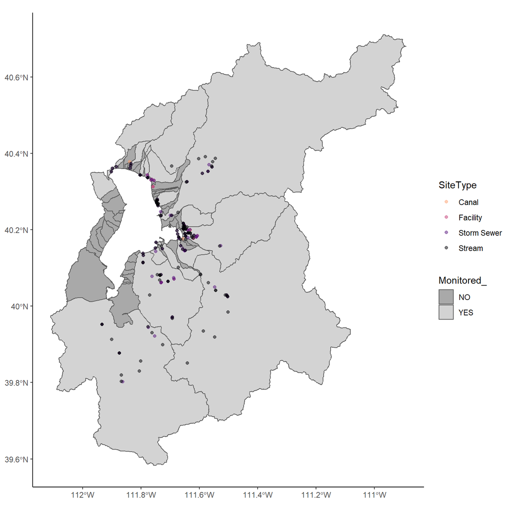

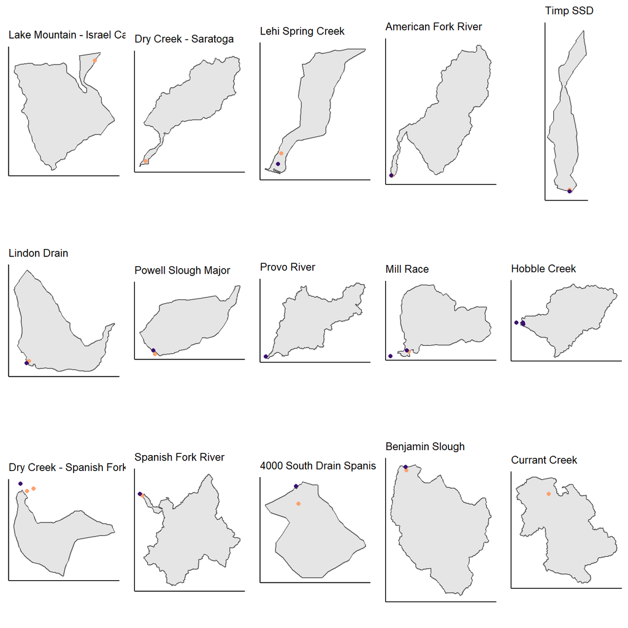

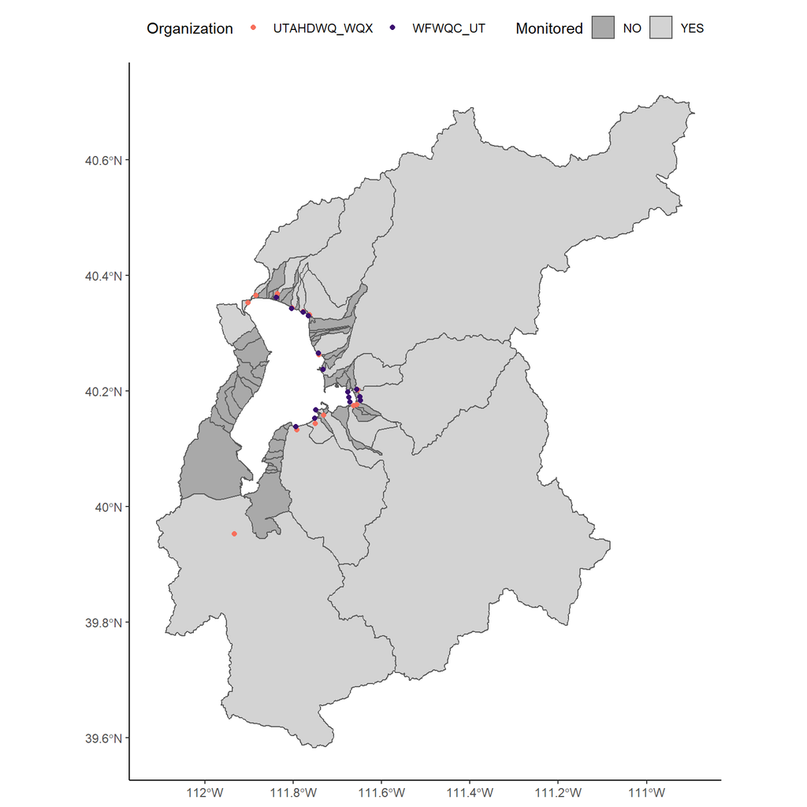

### Water Quality Time Series

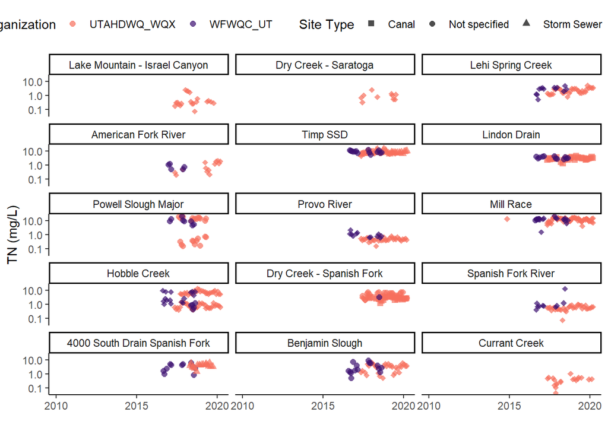

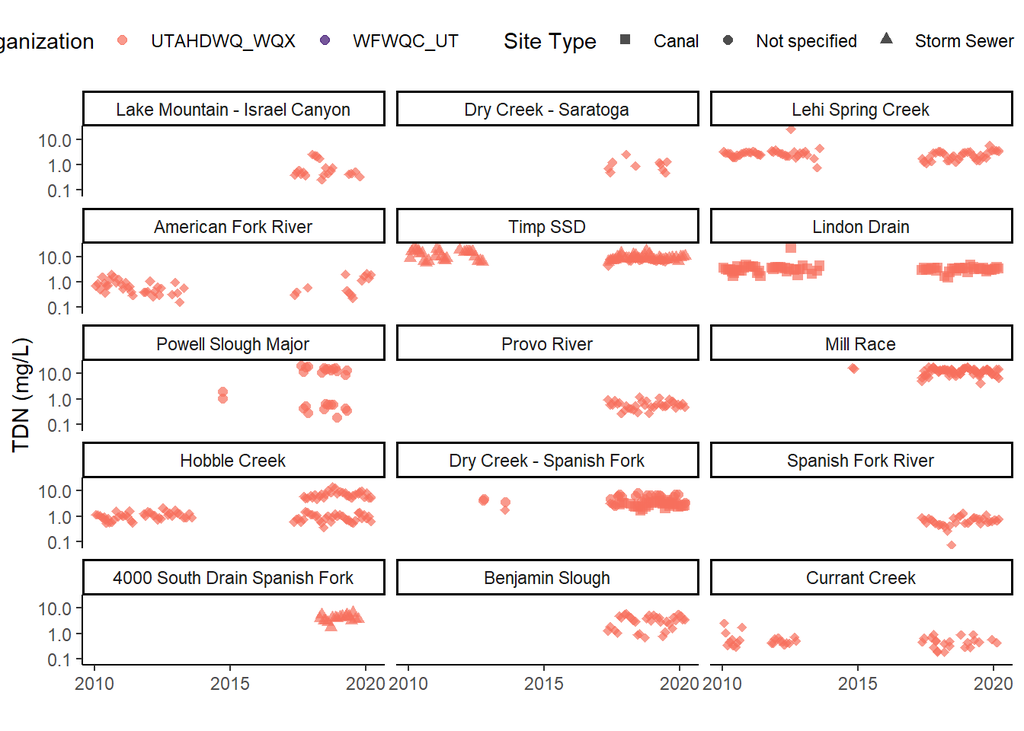

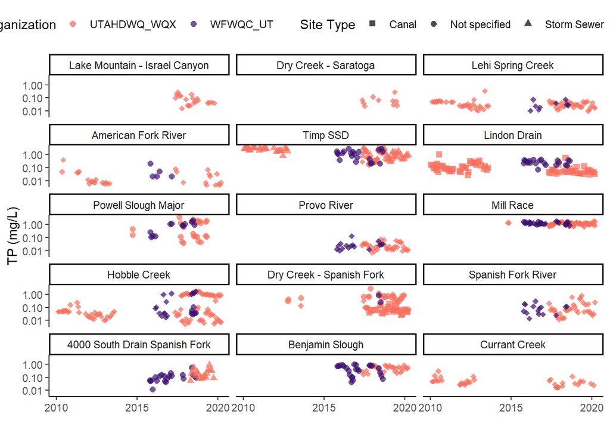

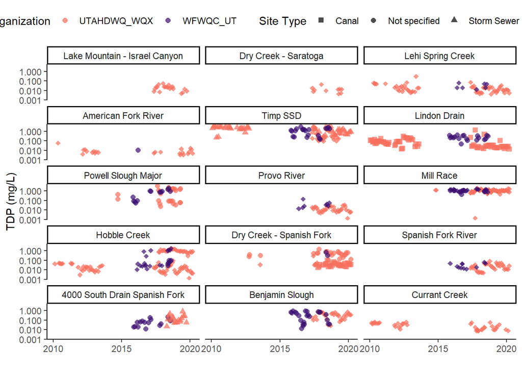

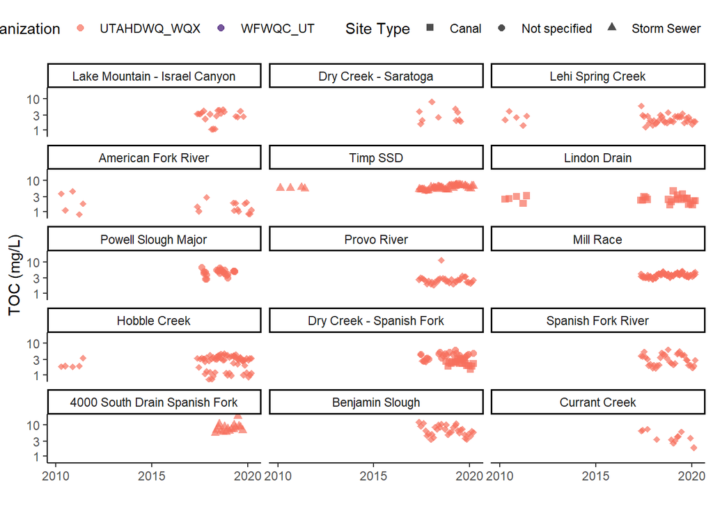

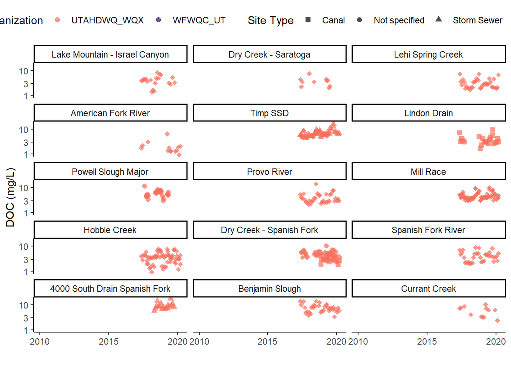

### Flow time series

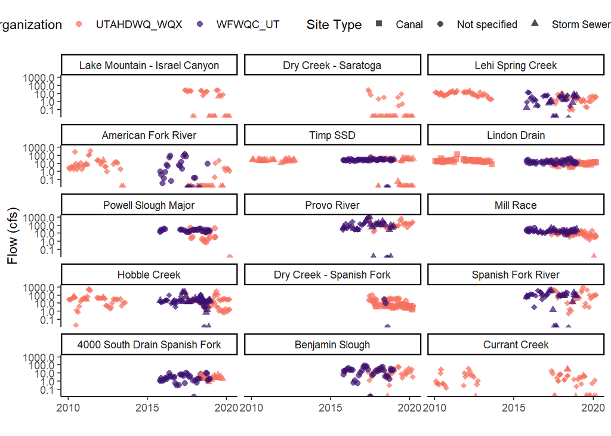

### Load time series

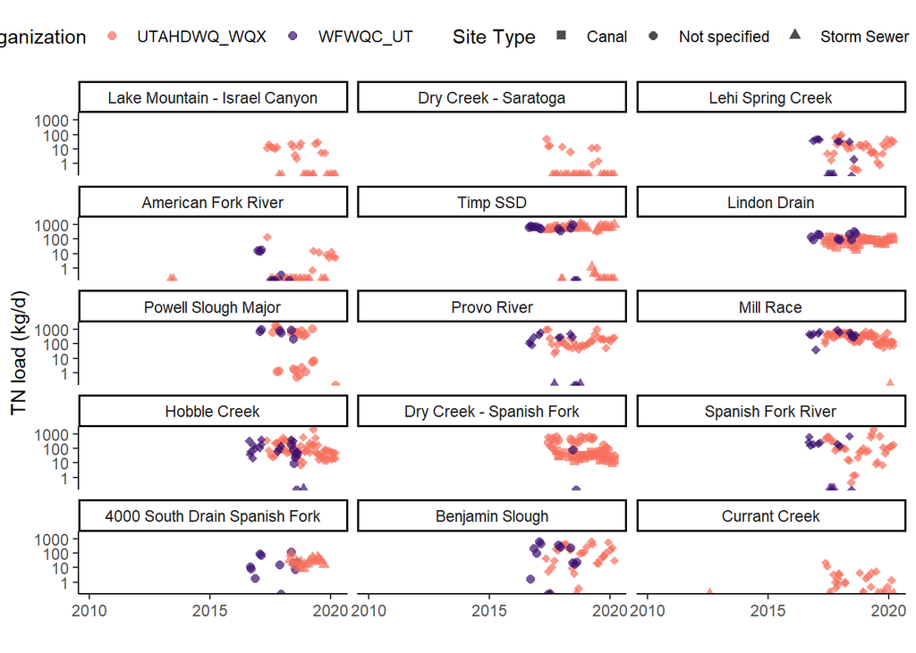

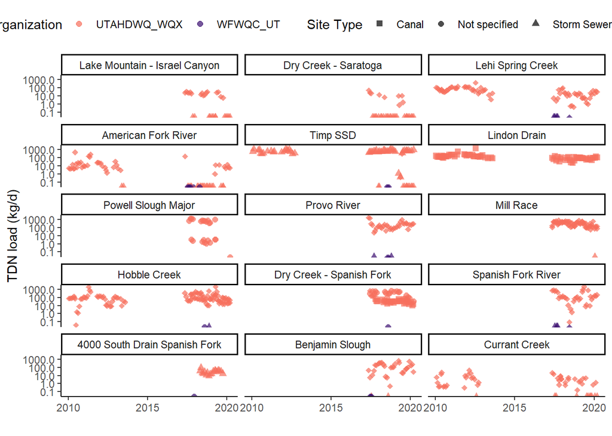

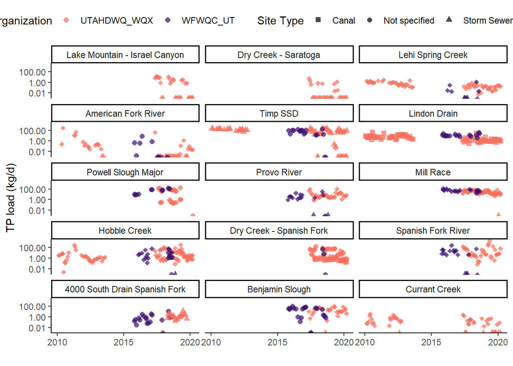

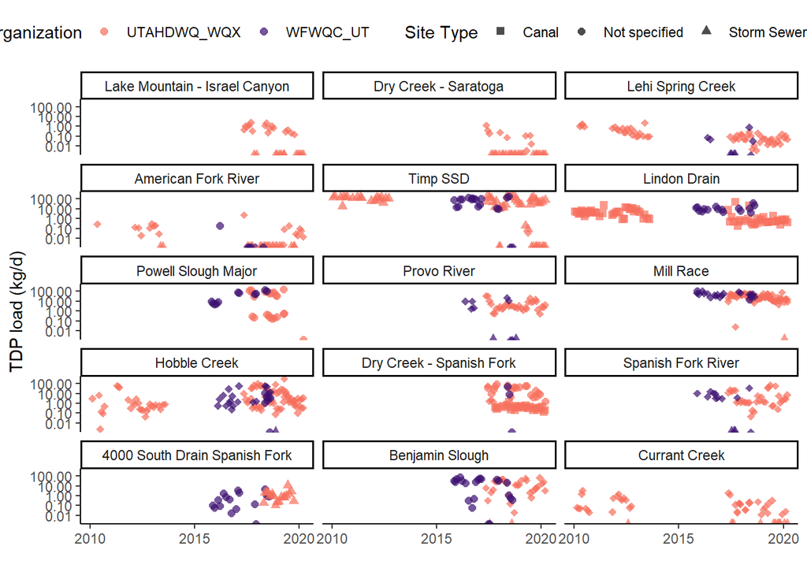

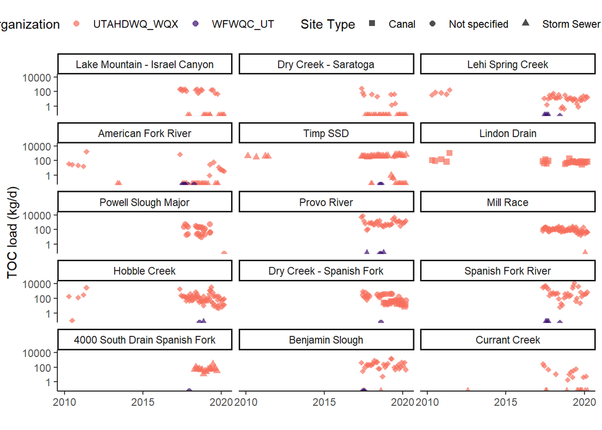

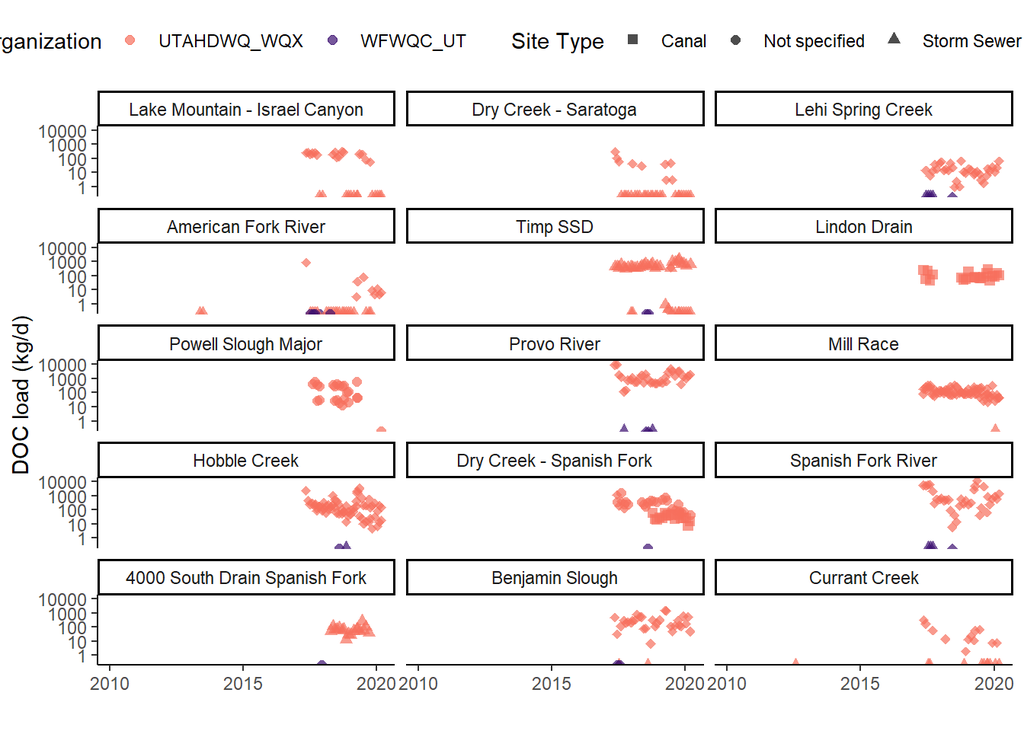

### Monthly conditions by watershed

#### Lake Mountain - Israel Canyon

There is only one inflow monitored in Lake Mountain - Israel Canyon. Estimates are based on this site.

Flow

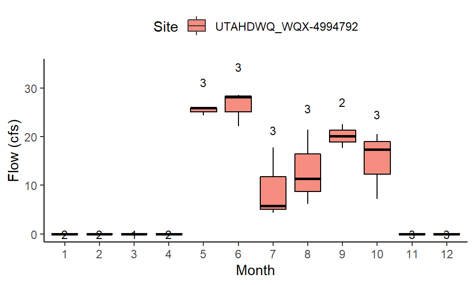

Nutrient loads

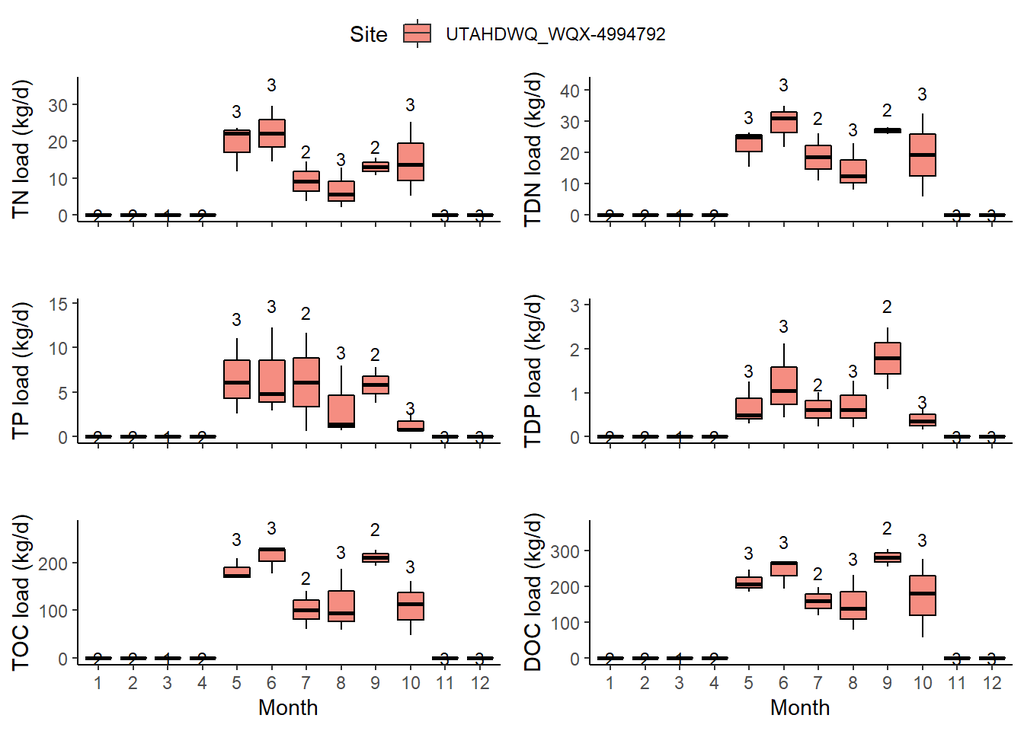

Calculate mean monthly loading

#### Dry Creek - Saratoga

There is only one inflow monitored in Dry Creek - Saratoga. Estimates are based on this site.

Flow

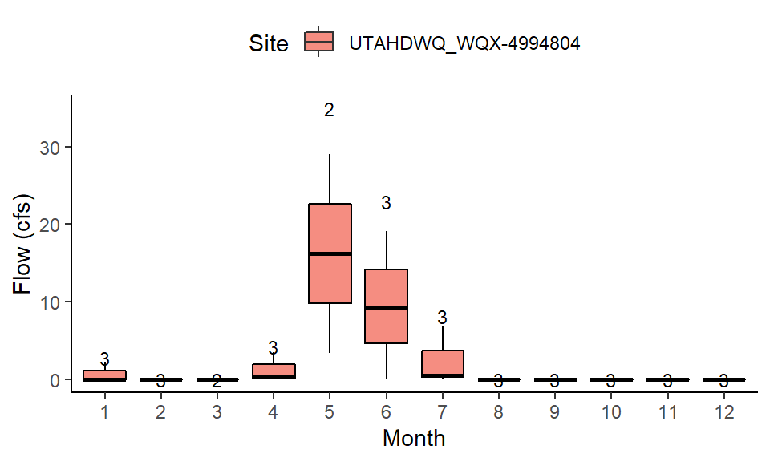

Nutrient loads

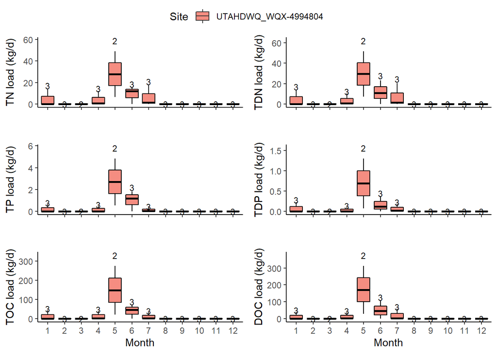

Calculate mean monthly loading

#### Lehi Spring Creek

There are two sites in Lehi Spring Creek. DWQ site is upstream of WFWQC site. Will compare loads to determine if the estimates can be combined.

Flow

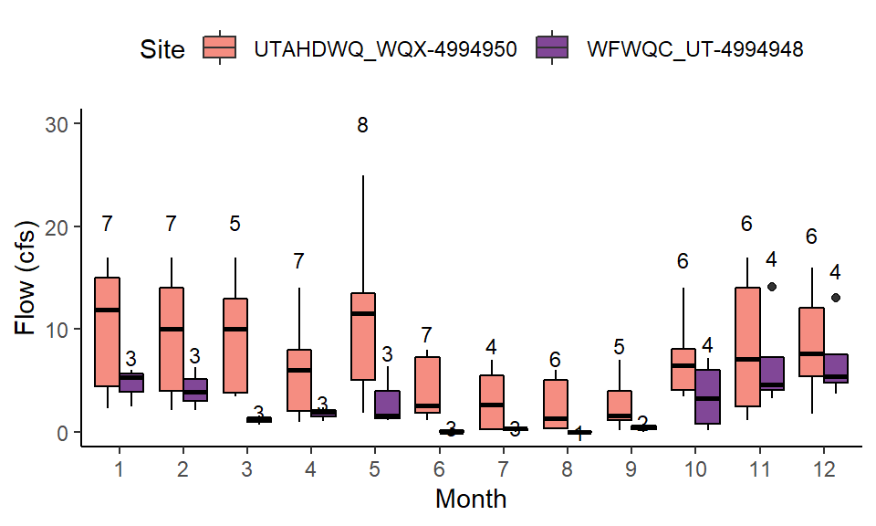

Nutrient loading

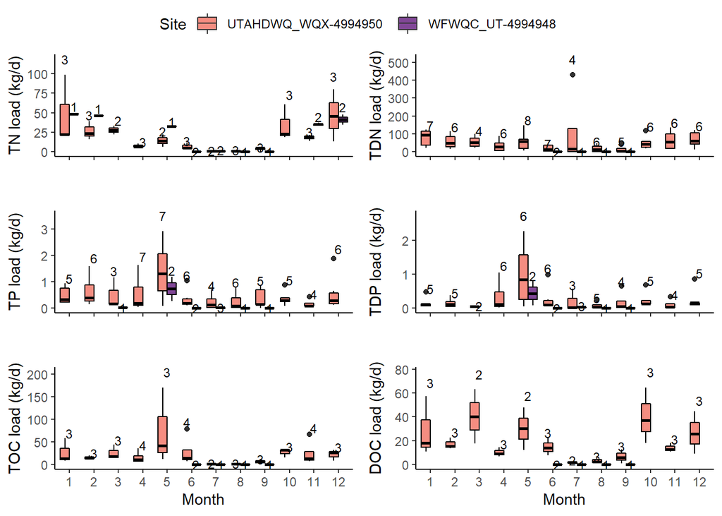

Calculate mean monthly loading

#### American Fork River

There are two sites in American Fork River. DWQ site is upstream of WFWQC site. Will compare loads to determine if the estimates can be combined.

Flow

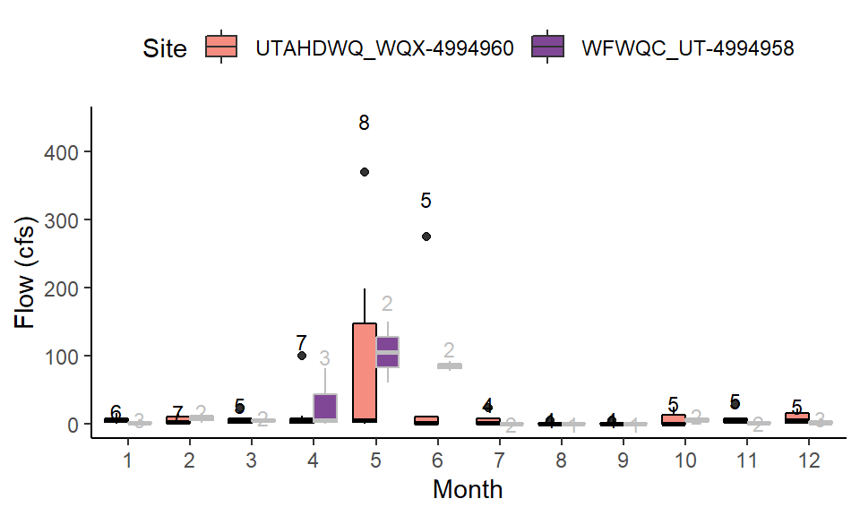

Nutrient loading

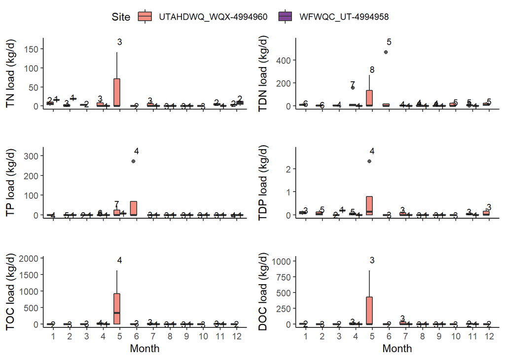

Calculate mean monthly loading

#### Timp SSD

Flow

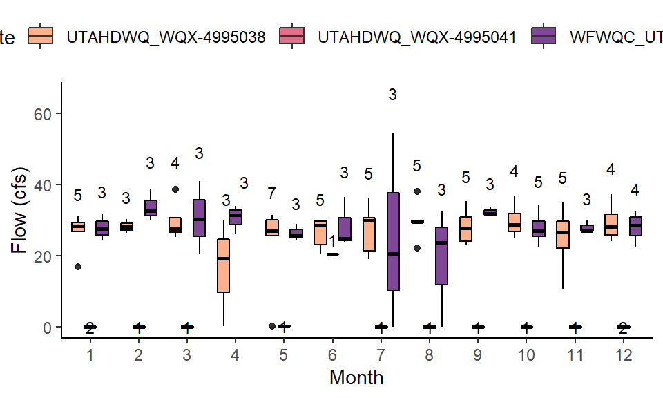

Nutrient loading

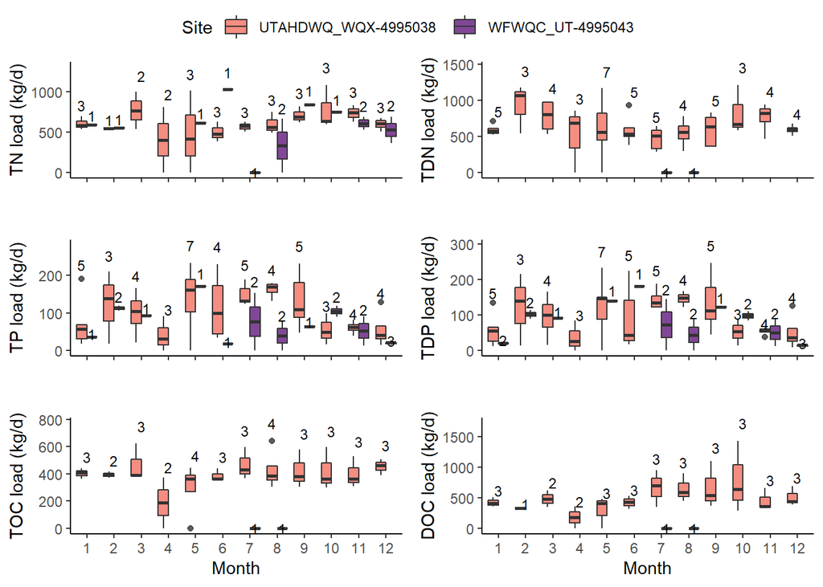

Calculate mean monthly loading

REVISIT East side tributary (UTAHDWQ_WQX-4995041) has measurable concentrations but no flow (one near-zero flow, one flow duplicated from 4995038). Scott’s recommendation was to average concentrations at 4995041 and 4995038 and apply them to the flow at 4995038, but this assumes that the volume-weighted average is the same as the arithmetic average (i.e., that the volumes at both sites are the same). I’m not sure if this assumption is valid. For now, I will ignore the east side tributary and calculate loads based on the sites that have flow data.

#### Lindon Drain

There are two sites in Lindon Drain. DWQ site is upstream of WFWQC site. Will compare loads to determine if the estimates can be combined.

Flow

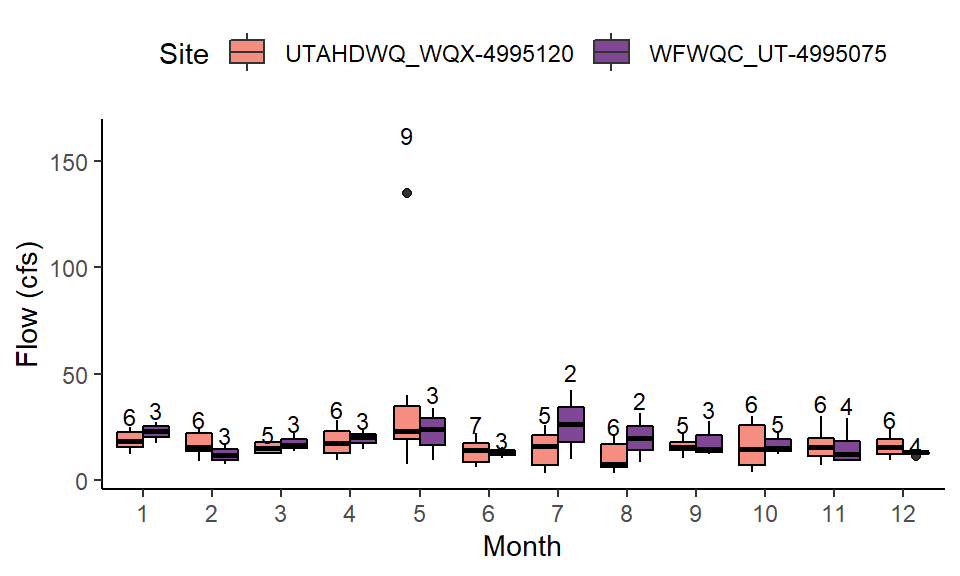

Nutrient loading

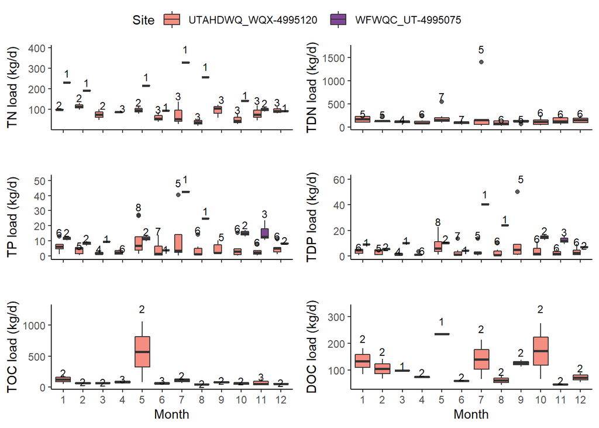

Calculate mean monthly loading

#### Powell Slough Major

Flow

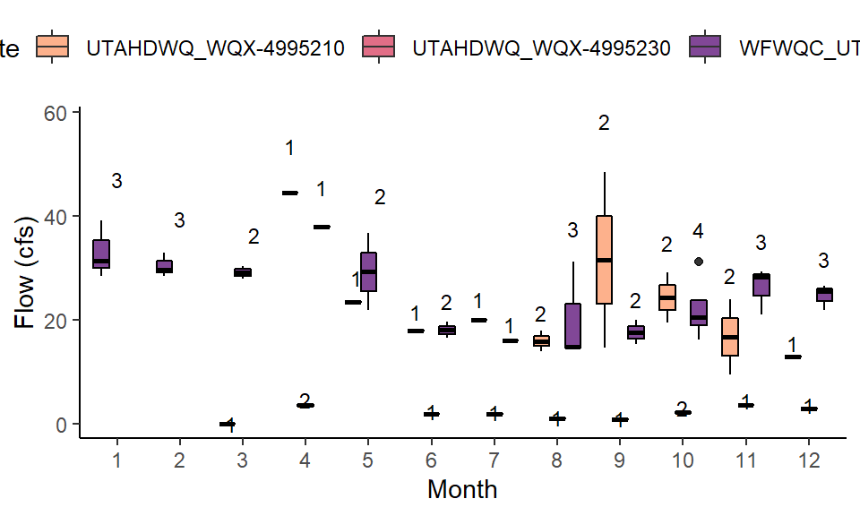

Nutrient loading

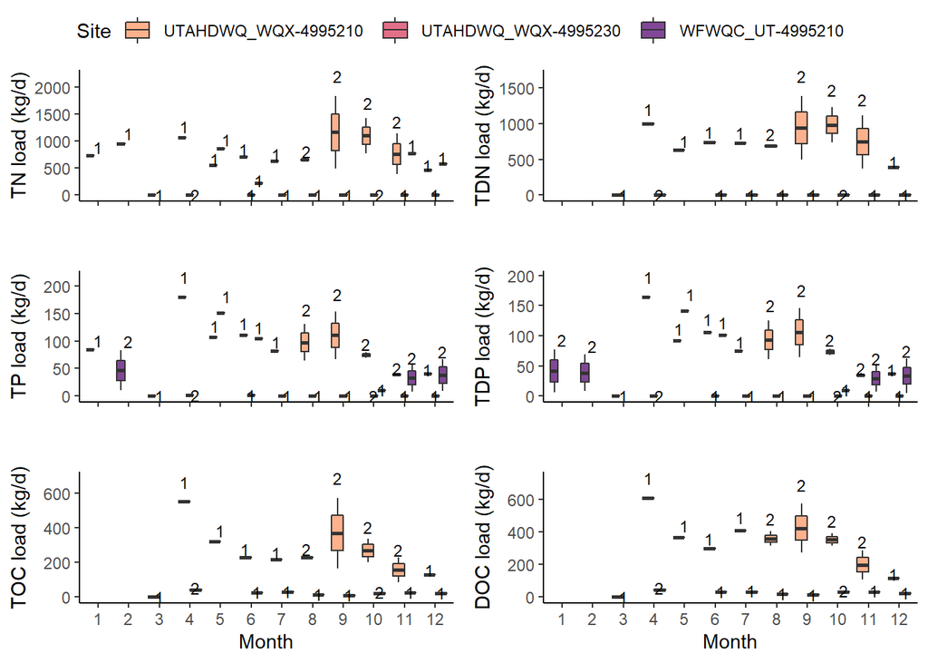

Calculate mean monthly loads

Powell Slough has both North and South outfalls. Need to add together load from North and South to compute total load. WFWQC samples only at the north outfall.